# Proje Rapor : PINAR NUR ÖZTÜRK 210401058

# Q1 : Problem tanımı

Şirketimiz **Green Consulting**. Problemimiz *günümüzde çevre kirliliği faktörleri ile nüfus artışı arasındaki karmaşık ilişki, çevresel politikaların etkin bir şekilde yönlendirilmesini zorlaştırmaktadır. Green Consulting, bu karmaşıklığı anlamak ve çevresel politikalar üzerindeki etkisini belirleyerek sürdürülebilir bir geleceği şekillendirmeyi amaçlamaktadır.*

# Q2 : Proje Amacı

**Çevre Kirliliği ve Nüfus Artışı İlişkisinin Analizi: Sürdürülebilir Geleceği Şekillendirmek** world-polluted-country-report ve [World Population Dataset](https://www.kaggle.com/datasets/iamsouravbanerjee/world-population-dataset) adlı Kaggle veri setlerini kullandığımız bu projenin temel amacı, *çevre kirliliği faktörleri ile nüfus artışı arasındaki karmaşık ilişkiyi anlamak ve bu ilişkinin çevresel politikalara etkisini belirlemektir.* Bu kapsamda, dünya genelindeki çevre kirliliği verilerini analiz ederek, çevre kirliliği ile nüfus artışı arasındaki ilişkiyi **kwantitatif** bir şekilde ortaya koymayı hedefliyoruz. Analiz etapları arasında, çevre kirliliği faktörlerini belirleme, nüfus artışı ile bu faktörler arasındaki ilişkiyi değerlendirme ve çevresel politikalara önerilerde bulunma yer almaktadır.Bu analizlerden elde edilen sonuçlar, çevre kirliliği ve nüfus artışı arasındaki ilişkinin derinlemesine anlaşılmasına katkı sağlayacak ve çevresel politikaların daha etkin bir şekilde yönlendirilmesine olanak tanıyacaktır. Ayrıca, sürdürülebilir bir geleceği şekillendirmek için önerilecek çözümler, çevresel sürdürülebilirlik alanında kritik öneme sahip olacaktır.

# Q3 : Veri seti keşifsel analizi

Veri setlerinin bilgileri aşağıda verilmiştir.

**World Polluted Country Report Dataset** - **Satir sayisi** : 96 - **Satir sayisi** : 12

**World Population Dataset** - **Satir sayisi** : 234 - **Satir sayisi** : 17

Veri setlerinin görselleştirmesi aşağıda verilmiştir.

**World Polluted Country Report Dataset**

| pollution_2023 | pollution_growth_Rate | country_name | ccn3 | country_region | united_nation_Member | country_land_Area_in_Km | pollution_density_in_km | pollution_density_per_Mile | share_borders | pollution_Rank | mostPollutedCountries_particlePollution |
| --- | --- | --- | --- | --- | --- | --- | --- | --- | --- | --- | --- |
| 1428627663 | 0.00808 | India | 356 | Asia | TRUE | 2973190.0 | 480.5033 | 1244.5036 | AFG, BGD, BTN, MMR, CHN, NPL, PAK, LKA | 1 | 58.08 |
| 1425671352 | -0.00015 | China | 156 | Asia | TRUE | 9424702.9 | 151.2696 | 391.7884 | AFG, BTN, MMR, HKG, IND, KAZ, PRK, KGZ, LAO, MAC, MNG, PAK, RUS, TJK, VNM | 2 | 39.12 |
| 339996563 | 0.00505 | United States | 840 | North America | TRUE | 9147420.0 | 37.1686 | 96.2666 | CAN, MEX | 3 | 9.04 |
| 277534122 | 0.00738 | Indonesia | 360 | Asia | TRUE | 1877519.0 | 147.8196 | 382.8528 | TLS, MYS, PNG | 4 | 51.71 |
| 240485658 | 0.01976 | Pakistan | 586 | Asia | TRUE | 770880.0 | 311.9625 | 807.9829 | AFG, CHN, IND, IRN | 5 | 65.81 |
| 223804632 | 0.02408 | Nigeria | 566 | Africa | TRUE | 910770.0 | 245.7312 | 636.4439 | BEN, CMR, TCD, NER | 6 | 21.40 |
| 216422446 | 0.00515 | Brazil | 76 | South America | TRUE | 8358140.0 | 25.8936 | 67.0645 | ARG, BOL, COL, GUF, GUY, PRY, PER, SUR, URY, VEN | 7 | 15.77 |
| 172954319 | 0.01033 | Bangladesh | 50 | Asia | TRUE | 130170.0 | 1328.6803 | 3441.2821 | MMR, IND | 8 | 83.30 |
| 144444359 | -0.00186 | Russia | 643 | Europe | TRUE | 16376870.0 | 8.8200 | 22.8439 | AZE, BLR, CHN, EST, FIN, GEO, KAZ, PRK, LVA, LTU, MNG, NOR, POL, UKR | 9 | 9.85 |
| 128455567 | 0.00746 | Mexico | 484 | North America | TRUE | 1943950.0 | 66.0797 | 171.1463 | BLZ, GTM, USA | 10 | 20.02 |

[output cut: 86 more lines]

**World Population Dataset**

| Rank | CCA3 | Country/Territory | Capital | Continent | 2022 Population | 2020 Population | 2015 Population | 2010 Population | 2000 Population | 1990 Population | 1980 Population | 1970 Population | Area (km²) | Density (per km²) | Growth Rate | World Population Percentage |
| --- | --- | --- | --- | --- | --- | --- | --- | --- | --- | --- | --- | --- | --- | --- | --- | --- |
| 36 | AFG | Afghanistan | Kabul | Asia | 41128771 | 38972230 | 33753499 | 28189672 | 19542982 | 10694796 | 12486631 | 10752971 | 652230 | 63.0587 | 1.0257 | 0.52 |
| 138 | ALB | Albania | Tirana | Europe | 2842321 | 2866849 | 2882481 | 2913399 | 3182021 | 3295066 | 2941651 | 2324731 | 28748 | 98.8702 | 0.9957 | 0.04 |
| 34 | DZA | Algeria | Algiers | Africa | 44903225 | 43451666 | 39543154 | 35856344 | 30774621 | 25518074 | 18739378 | 13795915 | 2381741 | 18.8531 | 1.0164 | 0.56 |
| 213 | ASM | American Samoa | Pago Pago | Oceania | 44273 | 46189 | 51368 | 54849 | 58230 | 47818 | 32886 | 27075 | 199 | 222.4774 | 0.9831 | 0.00 |
| 203 | AND | Andorra | Andorra la Vella | Europe | 79824 | 77700 | 71746 | 71519 | 66097 | 53569 | 35611 | 19860 | 468 | 170.5641 | 1.0100 | 0.00 |
| 42 | AGO | Angola | Luanda | Africa | 35588987 | 33428485 | 28127721 | 23364185 | 16394062 | 11828638 | 8330047 | 6029700 | 1246700 | 28.5466 | 1.0315 | 0.45 |
| 224 | AIA | Anguilla | The Valley | North America | 15857 | 15585 | 14525 | 13172 | 11047 | 8316 | 6560 | 6283 | 91 | 174.2527 | 1.0066 | 0.00 |
| 201 | ATG | Antigua and Barbuda | Saint John’s | North America | 93763 | 92664 | 89941 | 85695 | 75055 | 63328 | 64888 | 64516 | 442 | 212.1335 | 1.0058 | 0.00 |
| 33 | ARG | Argentina | Buenos Aires | South America | 45510318 | 45036032 | 43257065 | 41100123 | 37070774 | 32637657 | 28024803 | 23842803 | 2780400 | 16.3683 | 1.0052 | 0.57 |
| 140 | ARM | Armenia | Yerevan | Asia | 2780469 | 2805608 | 2878595 | 2946293 | 3168523 | 3556539 | 3135123 | 2534377 | 29743 | 93.4831 | 0.9962 | 0.03 |

[output cut: 224 more lines]

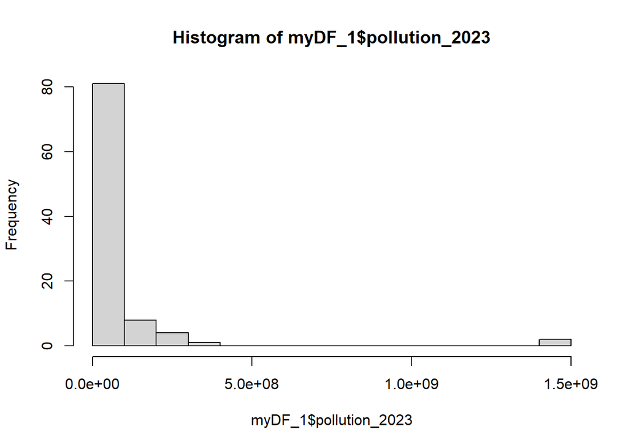

**Ülkelerdeki 2022 yılı nüfusları aşağıda belirtilmiştir.**

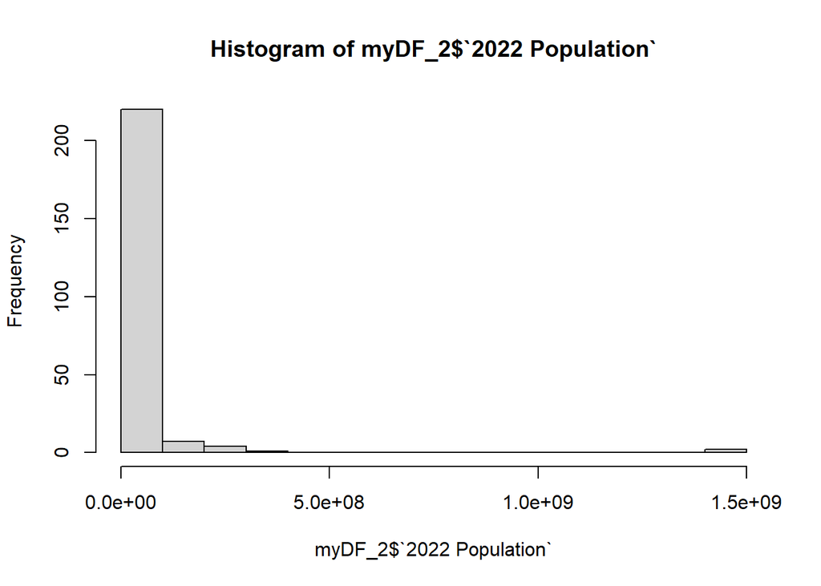

Ülkelerdeki kirlilik oranı 5.0’dann büyük değerlere sahip ülkeler aşağıda analiz edilmiştir.

[figure not shown]

2022 Nüfus oranı 41125771 büyük olan ülkeler

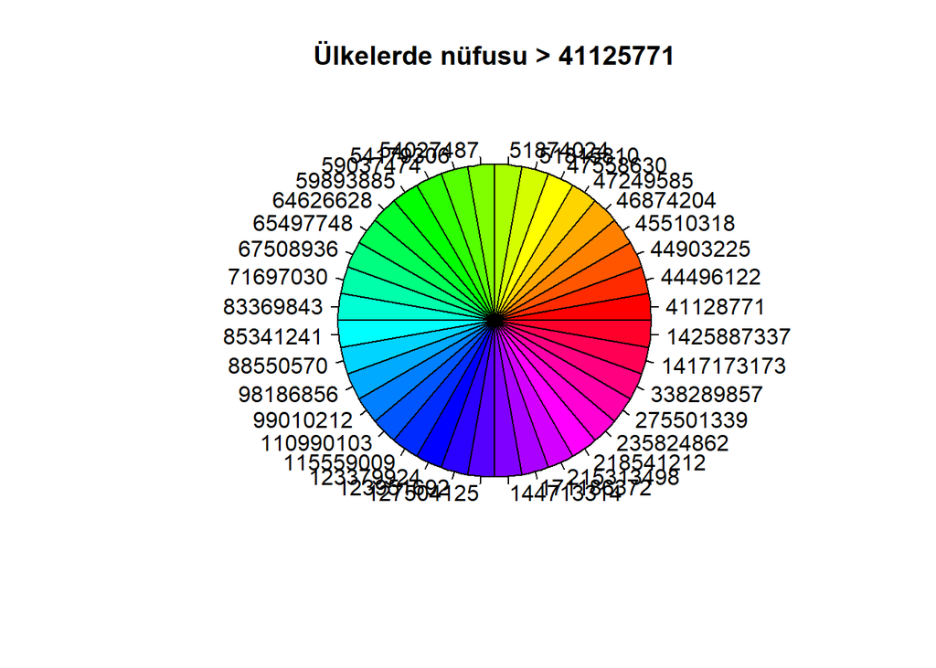

# Q4 : Veri seti ön işlemesi

**World Polluted Country Report Dataset** tablosunda sadece kirlilik oranlarının bulunduğu sütun ve ülkeler sütunu ayrı bir tablo olarak ayıklandı..

| country_name | pollution_2023 |
| --- | --- |
| India | 1428627663 |
| China | 1425671352 |
| United States | 339996563 |
| Indonesia | 277534122 |
| Pakistan | 240485658 |
| Nigeria | 223804632 |

**World Population Dataset** tablosunda sadece 2022 nüfuslarının bulunduğu sütun ve ülkeler sütunu ayrı bir tablo olarak ayıklandı..

| Country/Territory | 2022 Population |
| --- | --- |
| Afghanistan | 41128771 |
| Albania | 2842321 |
| Algeria | 44903225 |
| American Samoa | 44273 |
| Andorra | 79824 |
| Angola | 35588987 |

Tablolarda ham veri setleri okundu ve aşağıdaki adımlar uygulandı : *Country sütununu faktör tipine çevir* *Virgülle ayrılmış sayısal değerleri numeric tipine çevir* *Eksik veri temizleme*

| country_name | pollution_2023 |
| --- | --- |
| India | 1428627663 |
| China | 1425671352 |
| United States | 339996563 |
| Indonesia | 277534122 |
| Pakistan | 240485658 |
| Nigeria | 223804632 |

| Country/Territory | 2022 Population |
| --- | --- |
| Afghanistan | 41128771 |
| Albania | 2842321 |
| Algeria | 44903225 |
| American Samoa | 44273 |
| Andorra | 79824 |
| Angola | 35588987 |

# Q5 : Veri mühendisliği

**İki tablonun ülkeler bazında işlenebilmesi için birleştirildi ve yeni oluşan tablo aşağıdaki gibi oluşmuştur.**

| country_name | pollution_2023 |
| --- | --- |
| India | 1428627663 |
| China | 1425671352 |
| United States | 339996563 |
| Indonesia | 277534122 |
| Pakistan | 240485658 |
| Nigeria | 223804632 |
| Brazil | 216422446 |
| Bangladesh | 172954319 |
| Russia | 144444359 |
| Mexico | 128455567 |

[output cut: 86 more lines]

| Country/Territory | 2022 Population |
| --- | --- |
| Afghanistan | 41128771 |
| Albania | 2842321 |
| Algeria | 44903225 |
| American Samoa | 44273 |
| Andorra | 79824 |
| Angola | 35588987 |
| Anguilla | 15857 |
| Antigua and Barbuda | 93763 |
| Argentina | 45510318 |
| Armenia | 2780469 |

[output cut: 224 more lines]

| country_name | pollution_2023 | 2022 Population |
| --- | --- | --- |
| India | 1428627663 | 1417173173 |
| China | 1425671352 | 1425887337 |
| United States | 339996563 | 338289857 |
| Indonesia | 277534122 | 275501339 |
| Pakistan | 240485658 | 235824862 |
| Nigeria | 223804632 | 218541212 |
| Brazil | 216422446 | 215313498 |
| Bangladesh | 172954319 | 171186372 |
| Russia | 144444359 | 144713314 |
| Mexico | 128455567 | 127504125 |

[output cut: 86 more lines]

**Şimdi, bu birleştirilmiş veri seti üzerinde bir analiz yapalım**. Birleştirilmiş veri setinin kirlilik oranları ve 2022 nüfusunu içeren sütunlarının özet istatistiklerini ve iki değişken arasındaki ilişkiyi gösteren bir scatter plot yapıldı. Bu basit analizler, veri seti içeriği hakkında bir anlayış sağlamak için kullanılabilir. Summary fonksiyonu kullanıldı.

```
##      Min.   1st Qu.    Median      Mean   3rd Qu.      Max.
## 3.753e+05 5.882e+06 1.976e+07 7.405e+07 5.565e+07 1.429e+09
```

```
##      Min.   1st Qu.    Median      Mean   3rd Qu.      Max.
## 3.729e+05 5.823e+06 1.963e+07 7.352e+07 5.539e+07 1.426e+09
```

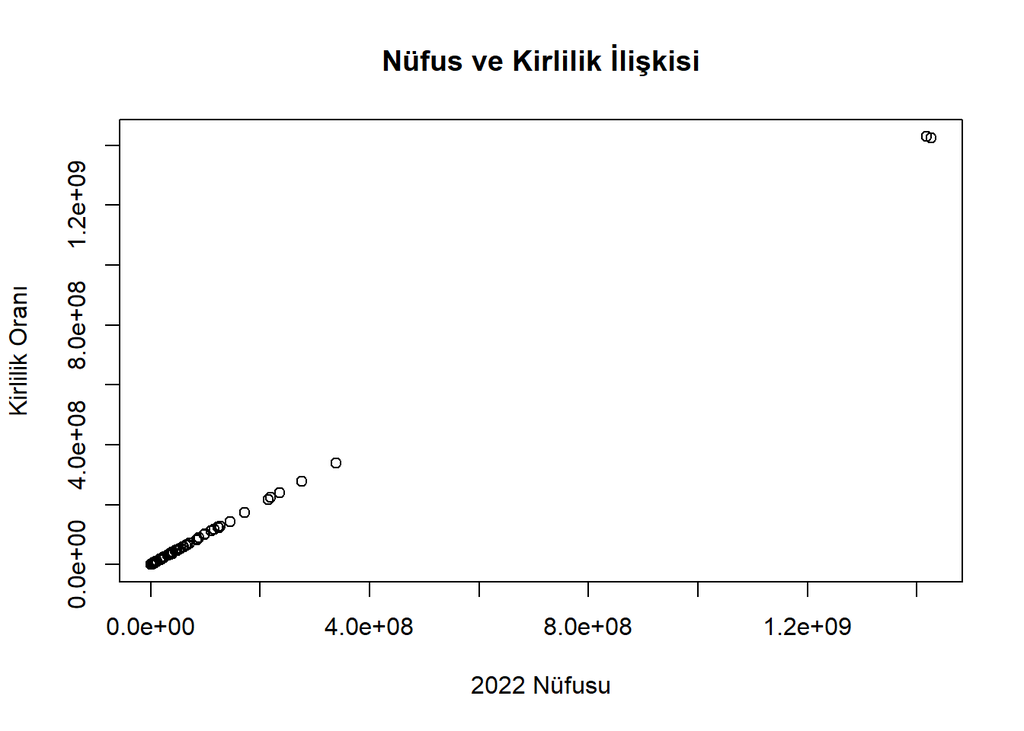

# Q6 : Veri analizi

**Birleştirilmiş veri seti üzerinde temel analiz**

```
##       country_name pollution_2023      2022 Population
##  Afghanistan: 1    Min.   :3.753e+05   Min.   :3.729e+05
##  Algeria    : 1    1st Qu.:5.882e+06   1st Qu.:5.823e+06
##  Angola     : 1    Median :1.976e+07   Median :1.963e+07
##  Argentina  : 1    Mean   :7.405e+07   Mean   :7.352e+07
##  Armenia    : 1    3rd Qu.:5.565e+07   3rd Qu.:5.539e+07
##  Australia  : 1    Max.   :1.429e+09   Max.   :1.426e+09
##  (Other)    :90
```

**Kirlilik ile nüfus artışı arasındaki ilişkiyi gösteren bir scatter plot**

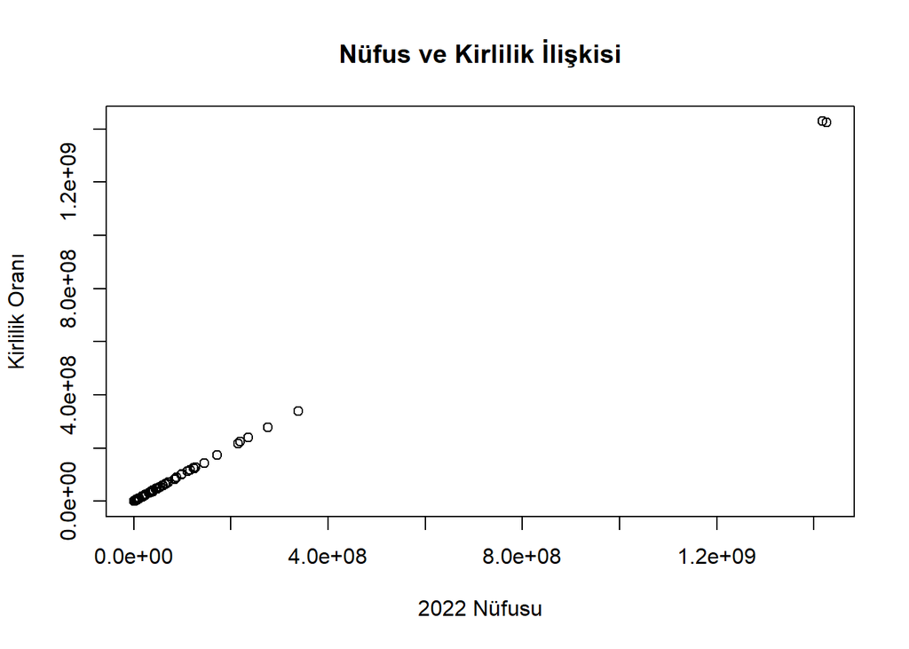

**Kirlilik ve nüfus artışı arasındaki korelasyon katsayısı**

```
## [1] "Korelasyon Katsayısı:  0.999983474732827"
```

**Nüfus artışı ile kirlilik arasındaki ilişkiyi lineer regresyon modeliyle inceleme**

```
##
## Call:
## lm(formula = pollution_2023 ~ `2022 Population`, data = merged_data)
##
## Residuals:
##      Min       1Q   Median       3Q      Max
## -6628533  -241830  -195478    13017  5079829
##
## Coefficients:
##                    Estimate Std. Error  t value Pr(>|t|)
## (Intercept)       2.130e+05  1.305e+05    1.633    0.106
## `2022 Population` 1.004e+00  5.955e-04 1686.434   <2e-16 ***
## ---
## Signif. codes:  0 '***' 0.001 '**' 0.01 '*' 0.05 '.' 0.1 ' ' 1
##
## Residual standard error: 1204000 on 94 degrees of freedom
## Multiple R-squared:      1,  Adjusted R-squared:      1
## F-statistic: 2.844e+06 on 1 and 94 DF,  p-value: < 2.2e-16
```

Bu kodlar, birleştirilmiş veri seti üzerinde temel analizler yapar. summary fonksiyonu, veri setinin özet istatistiklerini gösterir. Ayrıca, plot fonksiyonu ile nüfus artışı ve kirlilik arasındaki ilişkiyi gösteren bir scatter plot çizilir. cor fonksiyonu ile iki değişken arasındaki korelasyon katsayısı hesaplanır. Son olarak, lm fonksiyonu ile lineer regresyon modeli oluşturulur ve bu modelin özetini görüntüler.

Bu adımlar, çevresel kirlilik ile nüfus artışı arasındaki ilişkinin anlaşılmasına yönelik temel bir analiz sunar. Elde edilen istatistiksel sonuçlar ve grafikler, projenin ana hedefine ulaşmak için kritik öneme sahip olabilir ve çözüm tavsiyelerinin geliştirilmesine yardımcı olabilir.

# Q7 : Sonuç değerlendirme, tavsiyeler

Proje genelinde yapılan operasyonların geçerliliği, bulunan sonuçların yorumlanması ve proje hakkındaki değerlendirmeler aşağıda detaylı bir şekilde sunulmuştur:

**Sonuç Değerlendirme:** Proje, çevre kirliliği ile nüfus artışı arasındaki ilişkiyi inceleyerek çevresel politikalar için veri odaklı stratejiler geliştirmeyi amaçlamıştır. Bu kapsamda, “Dünya Kirli Ülke Raporu” ve “Dünya Nüfusu Veri Kümesi” adlı iki veri seti birleştirilerek çeşitli analizler gerçekleştirilmiştir.

**Projenin Ana Problemini Çözme Başarısı:** Proje, ana probleminin özüne odaklanarak çevresel kirlilik ile nüfus artışı arasındaki ilişkiyi anlamaya yönelik bir çözüm sağlamıştır. Bu, çevresel politikaların geliştirilmesinde ve sürdürülebilir bir geleceğin şekillendirilmesinde kullanılabilir.

**Sonuçların Kullanımı:** Bu analiz sonuçları, çevresel politika yapıcıları, çevre danışmanları ve sürdürülebilirlik uzmanları tarafından kullanılabilir. Elde edilen bilgiler, çevresel kirlilikle mücadelede ve nüfus artışının çevresel etkilerini azaltmaya yönelik stratejilerin belirlenmesinde rehberlik edebilir.

**Analizin ve Sonuçların Kuvvetli ve Zayıf Yanları:**

*Kuvvetli Yanlar:*

İki kapsamlı veri setinin birleştirilerek geniş bir perspektifin elde edilmiş olması. İstatistiksel analizlerin kullanılarak sayısal sonuçlar elde edilmesi.

*Zayıf Yanlar:*

Analizin daha fazla derinliğe inmemesi, örneğin, çevresel politika önlemlerinin etkinliği üzerinde daha fazla ayrıntılı bir analizin yapılması. Analizin daha fazla veri seti ve daha uzun bir zaman dilimi içermemesi.

**Tavsiyeler:**

İleriye yönelik çalışmalarda, daha fazla veri seti ve uzun vadeli verilerin kullanılması, daha güvenilir sonuçlara ulaşmak için faydalı olabilir. Çevresel politika önerilerinin daha spesifik ve uygulanabilir olması için daha fazla sektörel analiz yapılabilir. İlerideki çalışmalarda, çeşitli çevresel faktörlerin de analiz edilmesi, bu faktörlerin çevresel etkileşimlerini anlamak için önemli olacaktır.